# Taller 2

David Sanchez - Discord: lasagna#6231

11/4/2021

Este mismo codigo se puede encontrar en https://raw.githack.com/champagnepolo/Econometria-2/main/Talleres/TALLER2.html, y su respectivo Rmd en https://github.com/champagnepolo/Econometria-2/blob/main/Talleres/TALLER2.Rmd.

# 1 Tendencia

Considere el siguiente proceso

$$\tag{1}y_t=\alpha_0 + \alpha_1 t + \epsilon_t$$
Donde $\epsilon_t$es ruido blanco.

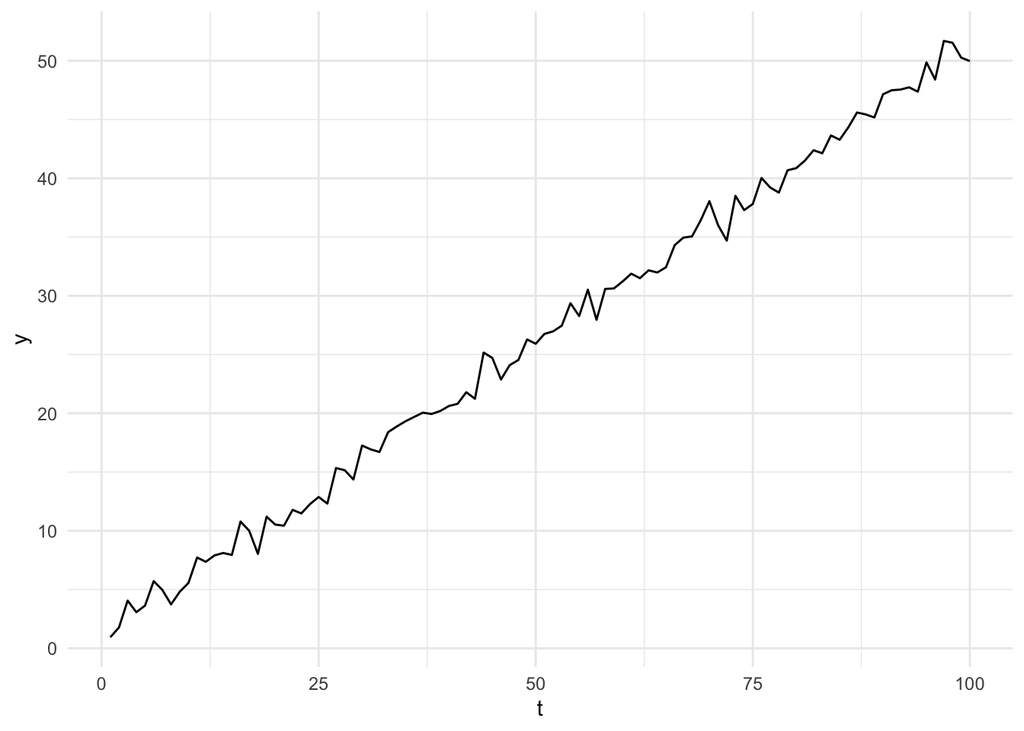

```r
t=seq(from=1,to=100,by=1)
set.seed(123)
e=rnorm(100)
a0=1
a1=0.5
df=data.frame(t,e)
df$y=a0+a1*t+e
ggplot(df,aes(x=t,y=y))+geom_line()+theme_minimal()
```

Si examina la ACF de este proceso se dará cuenta que no exhibe dependencia débil

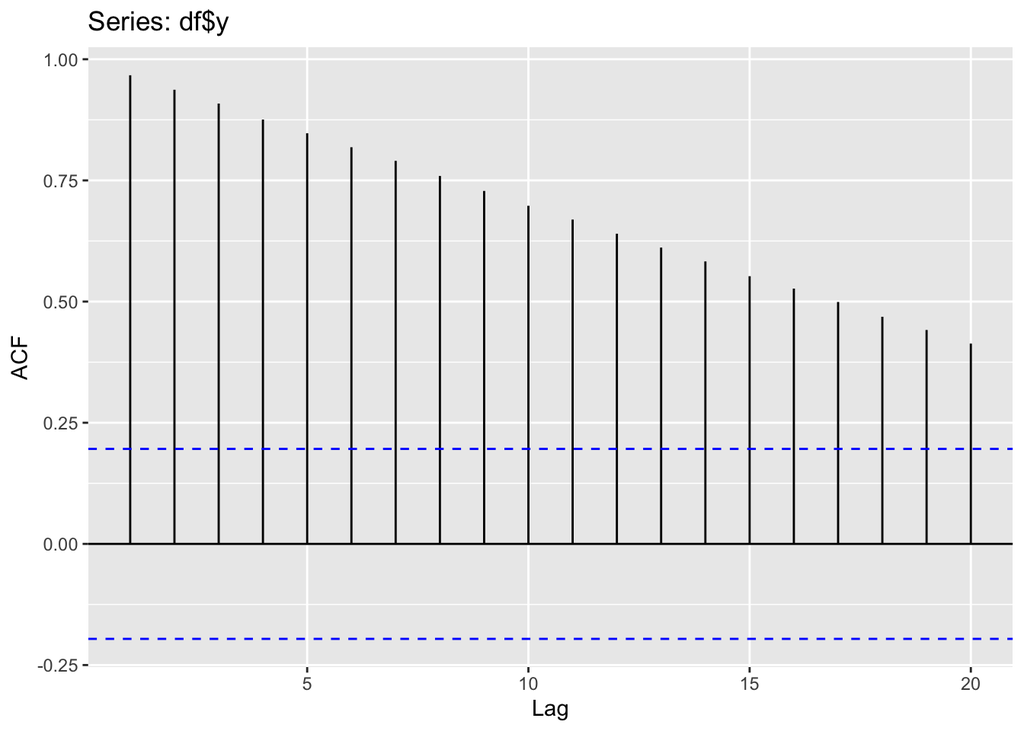

```r
ggAcf(df$y)
```

## 1.1 Ejercicio

Para el proceso (1) encuentre $E(yt)$ y $Var(yt)$ A partir de lo anterior explique porque el proceso no es estacionario en covarianza

Ahora, el proceso anterior se amplía con un término autoregresivo de orden 1, AR(1), con $−1<ϕ<1$, así

$$\tag{2}y_t=\alpha_0 + \alpha_1 t + ϕy_{t-1} + \epsilon_t$$

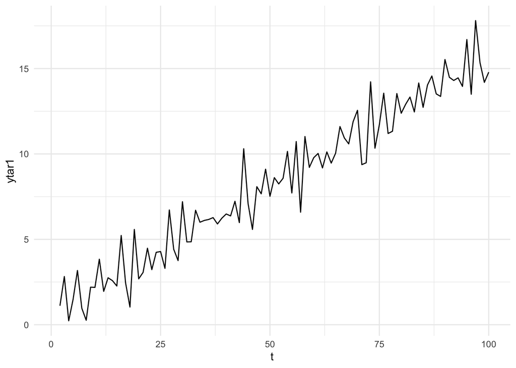

```r
phi=-0.7
library(fpp3)
df=as_tsibble(df,index=t)
df=df%>%mutate(ytar1=a0+a1*t+phi*lag(y,n=1L)+e)
ggplot(df,aes(y=ytar1,x=t))+geom_line()+theme_minimal()
```

Como se observa, esta serie es muy similar a la anterior. Si calcula y grafica la ACF obtiene

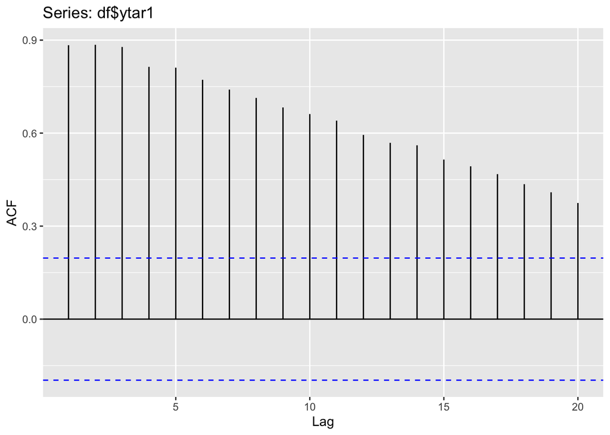

```r
ggAcf(df$ytar1)
```

## 1.2 Ejercicio

Para el proceso (2) encuentre $E(yt)$ y $Var(yt)$ A partir de lo anterior explique porque el proceso no es estacionario en covarianza

Simule nuevamente el proceso (2) pero con $\alpha_1=0$ Grafique la linea temporal y la ACF. Calcule la media, la varianza y las autocorrelaciones para este proceso ¿Es estacionario?

$$\tag{Paso 1}y_t=a_o + a_1t + r_t$$
$$\tag{Paso 2}y_t- ŷ_t$$

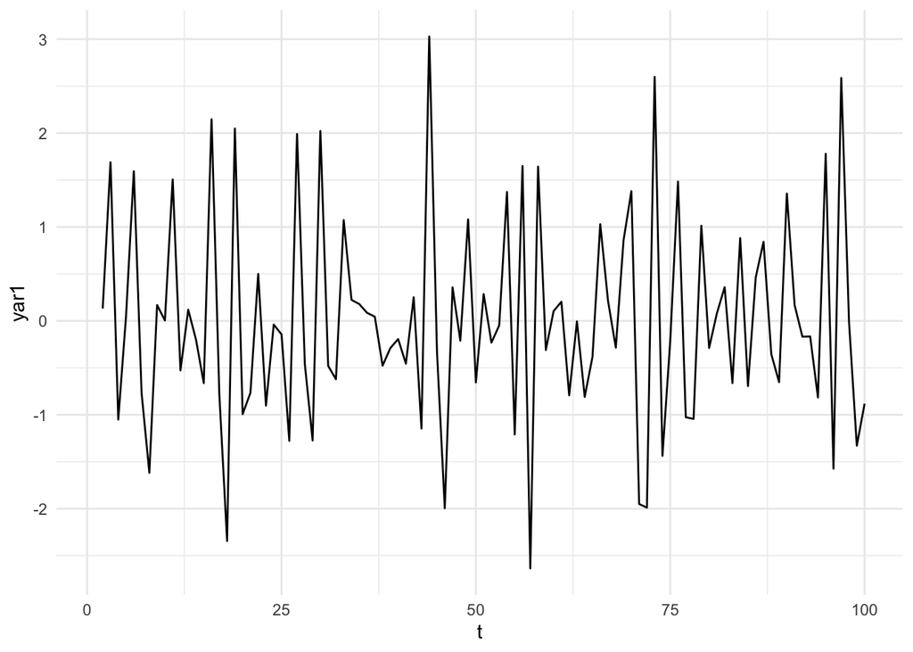

```r
detrend=lm(ytar1~t,data=df)
ythat=predict(detrend)
t=seq(from=2,to=100,by=1)
ythat=data.frame(cbind(t,ythat))
df=merge(df,ythat,all.x=TRUE)
df=df%>%mutate(yar1=ytar1-ythat)
ggplot(df,aes(x=t,y=yar1))+geom_line()+theme_minimal()
```

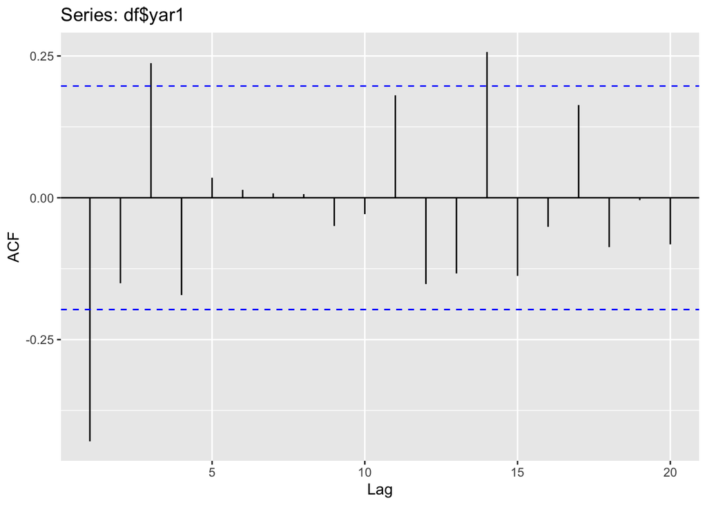

```r
ggAcf(df$yar1)
```

## 1.3 Ejercicio

Estime el modelo autoregresivo $y∗t=α_0+ϕy∗_{t−1}+e_t$, donde y∗ es la variable sin la tendencia

# 2 Tendencia estocástica

Considere ahora el siguiente proceso, caminata aleatoria con deriva
$$\tag{3}y_t=c+y_{t-1}+\epsilon_t$$

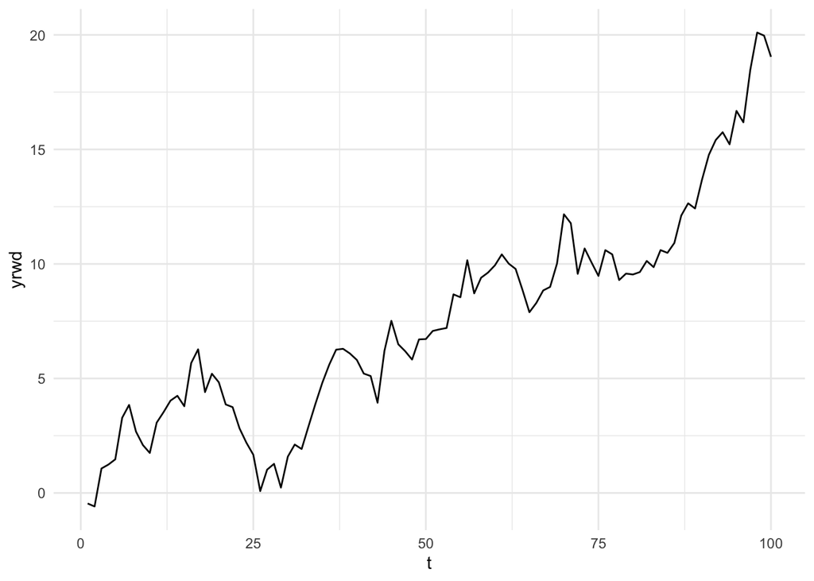

```r
c=0.1
df=df%>%mutate(yrwd=c*t+cumsum(e))
ggplot(df,aes(x=t,y=yrwd))+geom_line()+theme_minimal()
```

## 2.1 Ejercicio

Resuelva por iteración el proceso (3) y muestre que la pendiente de la tendencia temporal la determina c

$$\tag{1}y_t=c+y_{t-1}+\epsilon_t$$

$$\tag{2}y_{t+1}=c+(c+y_{t-1}+\epsilon_{t})+\epsilon_{t+1}$$
$$\tag{3}y_{t+1}=2c+y_{t-1}+e_t+e_{t+1}$$
$$\tag{4}y_{t+2}=3c+ y_{t-1}+e_t+e_{t+1}+e_{t+2}$$
$$\tag{5}y_{t+3}=4c+y_{t-1}+e_t+e_{t+1}+e_{t+2}+e_{t+3}$$
Si este proceso sigue T veces, la formula quedaria de la siguiente forma:

$$\tag{6}y_{t+T}=(t+T)c+y_{t-1}+\sum_{i=1}^{\infty} \epsilon_t$$

Si nos devolvemos nuevamente a la ecuacion 1 $y_t=c+y_{t-1}+\epsilon_t$, esta puede ser transformada al cambio de y, quedando de la siguiente manera

$$\tag{7}y_t-y_{t-1}=y\Delta=c+\epsilon_t$$
De esta manera podemos llegar a la inferencia de que $y_t$ se deriva hacia arriba o hacia abajo, dependiendo si $c$ es positivo o negativo, afectando asi, la direccion de la pendiente.

## 2.2 Ejercicio

Modifique el valor de c por uno negativo. Verifique que la tendencia ahora es negativa

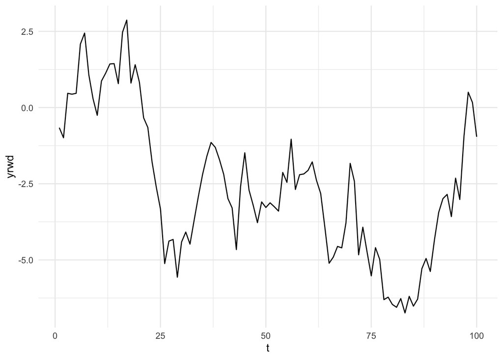

```r
c=-0.1
df=df%>%mutate(yrwd=c*t+cumsum(e))
ggplot(df,aes(x=t,y=yrwd))+geom_line()+theme_minimal()
```

Se puede evidenciar graficamente al momento de colocar $c$ negativo, que este tendra una tendencia hacia abajo (negativa), a contario de la grafica anterior, que esta tendia hacia arriba (positiva).

## 2.3 Ejercicio

Grafique la ACF. Interprete.

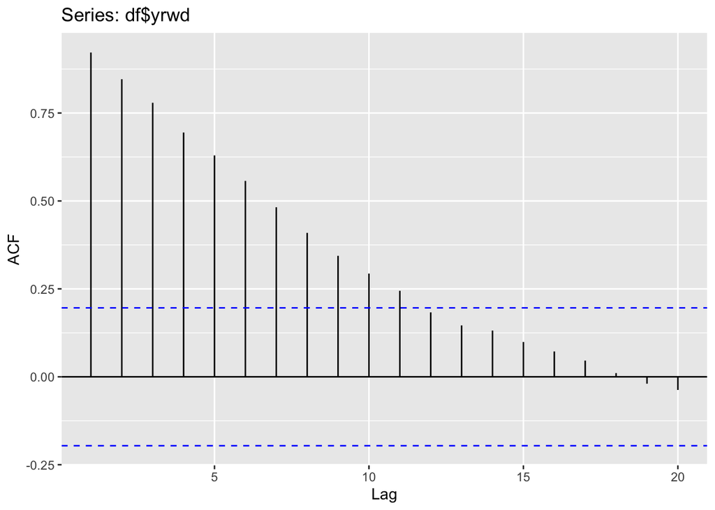

```r
ggAcf(df$yrwd)
```

Encontramos en la ACF picos estadisticamente siginficantes para lags hasta de 11. Lo que quiere decir que en dicho ejemplo, los choques tienden a afectar por un largo plazo en el tiempo.

## 2.4 Ejercicio

Para el proceso anterior, caminata aleatoria con deriva, podemos tomar la primera diferencia

$$\tag{4}\Delta y_t=c+e_t$$
Explique porque al tomar la primera diferencia el proceso es ahora estacionario